# Shaikh_ALY6000Project2

2023-01-23

**ALY6000 Introduction to Analytics**  
**Northeastern University**  
Professor: Dr. Dee Chiluiza  
Shaikh Rahheb  
Date: 01 February, 2023

Project Report - Week 2

**Introduction:**

The need for Descriptive and Inferential Statistics:

Before answering the above question I would like to put some light upon why do we use statistics in the first place? We use statistics as it is the center point of analytics. It gives us an insight of the current on going trends and past trends which can be used for example by the big business industries to make plans for the foresight and also learn from their past mistakes and can can handle it way better.  
Now we can answer the difference between Differential and Inferential statistics. First and foremost, Differential statistics makes use of the data presented and gives the features of a certain category or group whereas in Inferential statistics, it makes generalizations about the groups. Descriptive Statistics organises the data in a much more factual way whereas Inferential is used to make predictions. Descriptive is used when when the required result should be in a table or chart formats whereas in Inferential statistics the outcome is generally a probability. The conclusions also differ with Descriptive data show in results of the known data whereas Inferential goes above that data.([3] careerfoundry.com, 2021)

The need for proper Data presentation:

As humans we evolved mostly by using our visual systems and it has been developing since a really long time. Owing to that fact humans are mostly dependant on thier visual nervous systems more than any other sensory systems to gather information. We like learning visually making the presentatioon of data that much more important and necessary. Many people struggle with numbers when presented in the form of just tables that contains rows and columns making it difficult to read and also missing out on crucial information. To prevent these kinds of problems we must use better presentation tools which are presneted to us. Using diagrams like pie charts, box plots and histograms we can make data a much more readable and helpful method of study. The morebasic it is to read data the better it is. ([4] skillsyouneed.com, 2019)

Practical applications of R:  
R can be considered as one of the best tools when it comes to handling or representing data in today’s day and age. We can use this data representation tools for many applications and industries such as the  
*Finance Industry*: In Finance Industry R is widely used to visualize data for better risk management and also performance by using many of its tools like the candlestick charts and density plots.  
*Banking Industry:*In the banking industry they use R programming for Mortgage Haircut Models wherein the bank can take over the supposed property in case of a loan fraud.  
*Healthcare Industry:* IN the Health Industry, many institutes use R to crunch the data that is crucial for survival. R is most commonly used for doing pre-clinical studies and assessing drug-safety data in more complex processes such as drug development. It also gives its customers with a suite for undertaking exploratory data analysis as well as dynamic visualization capabilities. ([5] data-flair.training, 2019)

# Tasks:

```r
# Libraries used in this document
library(rmarkdown)
library(readxl)
library(readr)
library(tidyverse)
library(dplyr)
library(knitr)
library(kableExtra)
library(magrittr)
library(kableExtra)
library(RColorBrewer)
```

```r
# Data Sets used in this document
M2Data <- read_excel("C:/Users/Raheb/Desktop/ALY6000 Rproject/DataSets/M2Data.xlsx")
```

# Task 1

```r
# a) Isolate first 5
head1 = head(M2Data, 5)
# b) Isolate last 5
tail1 = tail(M2Data, 5)
# c) Combining them
HT = rbind(head1, tail1)
# d) Present using knitr::kable()
knitr::kable(HT)
```

| Region | Market | Company_Segment | Product_Category | Product_SubCategory | Price | Quantity | Sales | Profits | ShippingCost |
| --- | --- | --- | --- | --- | --- | --- | --- | --- | --- |
| Central US | USCA | Consumer | Technology | Phones | 221.98 | 2 | 443.96 | 62.15 | 40.77 |
| Oceania | Asia Pacific | Corporate | Furniture | Chairs | 3709.40 | 9 | 33384.60 | -288.77 | 923.63 |
| Oceania | Asia Pacific | Consumer | Technology | Phones | 5175.17 | 9 | 46576.53 | 919.97 | 915.49 |
| Western Europe | Europe | Home Office | Technology | Phones | 2892.51 | 5 | 14462.55 | -96.54 | 910.16 |
| Western Africa | Africa | Consumer | Technology | Copiers | 2832.96 | 8 | 22663.68 | 311.52 | 903.04 |
| Eastern Asia | Asia Pacific | Consumer | Furniture | Tables | 2614.69 | 7 | 18302.83 | -821.96 | 203.26 |
| Western US | USCA | Corporate | Office Supplies | Appliances | 69.48 | 1 | 69.48 | 20.84 | 12.04 |
| Oceania | Asia Pacific | Consumer | Technology | Copiers | 636.78 | 2 | 1273.56 | 286.50 | 203.20 |
| South America | LATAM | Corporate | Furniture | Bookcases | 2751.20 | 10 | 27512.00 | 110.00 | 203.13 |
| Southeastern Asia | Asia Pacific | Corporate | Technology | Phones | 1587.00 | 3 | 4761.00 | -76.56 | 203.08 |

**Observations**: Here we can observe that by using the syntaxes head(), tail(), and rbind() we have successfully printed the first 5 the last 5 and also created an object that holds the combined values of the printed tables.

# Task 2

```r
Market = M2Data %>% count(Market)
knitr::kable(Market)
```

| Market | n |
| --- | --- |
| Africa | 54 |
| Asia Pacific | 365 |
| Europe | 248 |
| LATAM | 133 |
| USCA | 200 |

**Observations**: We successfully created a table with all the categories of Market, and their corresponding frequencies.

# Task 3

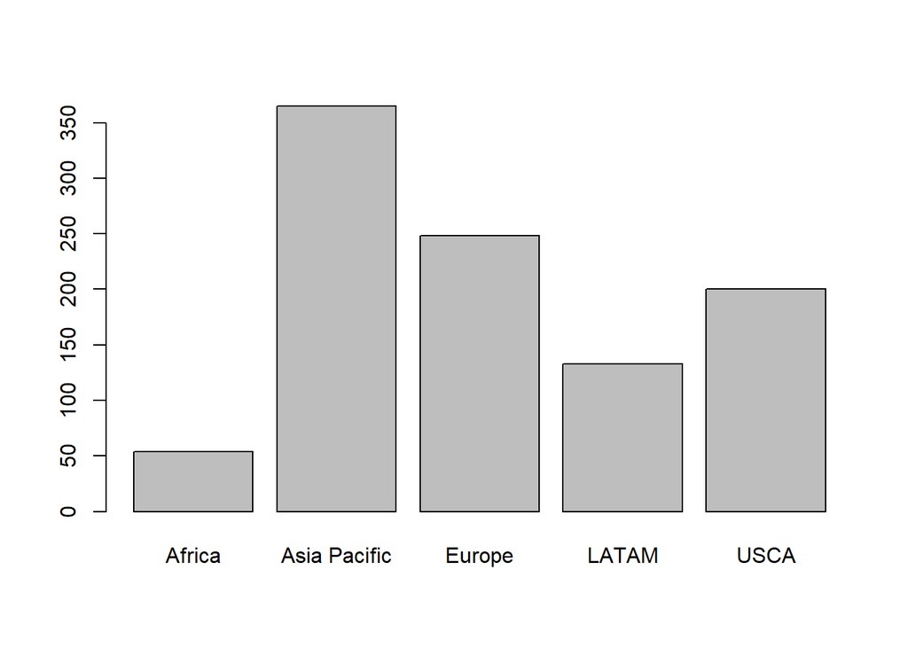

```r
graph1 = table(M2Data$Market)

barplot(graph1)
```

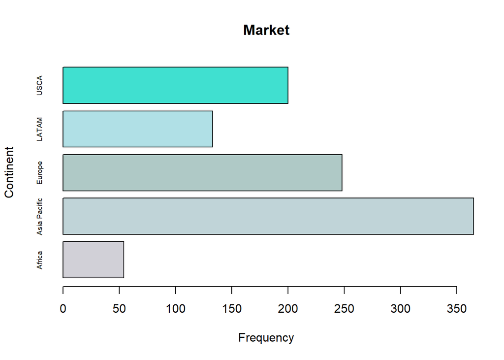

```r
par(main=c(1, 1.4, 1, 1))
plot1 = barplot(graph1,
                main = "Market",
                xlab = "Frequency",
                ylab = "Continent",
                col = c(
                  "#d1d0d7","#c0d4d8","#afc9c6","#b0e0e6","#40e0d0"),
                horiz = T,
                cex.names = 0.6
                )
```

**Observations**: We have successfully created the required bar graph and also added colors and made the values visible. We can observe that the Markets in Asia Pacific has the biggest values wehn compared to hte rest of the continents.